# Automated Parking 18xx Users Guide

# Overview of 18xx Automated Parking Demo

This lab demonstrates the use of TI mmWave sensors for Automated Parking applications. The range, velocity, and angle data from mmWave sensors can enable the detection of vehicles, pedestrians or objects.

Key features in this lab:

- use of multi-mode sub-frames to enable 3D detection at close range (0-10m) and 2D detection at longer range (0-50m)

The lab runs on the TI mmWave sensor AWR1843AOP EVM or AWR1843BOOST EVM and includes a MATLAB visualizer.

# Requirements

## Prerequisite

*Run Out of Box Demo* Before continuing with this lab, users should first run the mmWave SDK out of box demo for the EVM and become familiar with the mmWave SDK User’s Guide and the configuration format documented in section , 3. 4. Configuration (.cfg) File Format of the user guide This will enable users to gain familiarity with the sensor’s capabilities as well as the various tools used across all labs in the Radar Toolbox.

## Required and Supported mmWave Evaluation Modules (EVM)

### AWR1843BOOST EVM

| Quantity | Item |
| --- | --- |
| 1 | EVM: AWR1843BOOST |

OR

### 1843AOP EVM

| Quantity | Item |
| --- | --- |
| 1 | EVM: AWR1843AOPEVM |
| 1 | OPTIONAL: [mmWave Carrier Board](http://www.ti.com/tool/MMWAVEICBOOST) for CCS based debugging |

## Additional Hardware Requirements

[output not shown]

## Software

[output not shown]

# Quickstart

The quickstart guide will cover setting up the EVM, flashing firmware, and running the demo.

## 1. Setup the EVM for Flashing Mode

- For AOP in Standalone/Modular Mode: Follow the instructions for Hardware Setup of AWR1843AOP EVM for Flashing Mode
- For AWR1843BOOST setup: Follow the instructions for Hardware Setup of AWR1843BOOST EVM for Flashing Mode

## 2. Flash the EVM using Uniflash

Flash the binary listed below using UniFlash. Follow the instructions for using UniFlash

| BIN Name | Board | Location |
| --- | --- | --- |
| parking_18xx_demo_aop.bin | AWR1843AOPEVM | `prebuilt_binaries\aop` |
| parking_18xx_demo_boost.bin | AWR1843BOOST | `prebuilt_binaries\boost` |

## 3. Setup the EVM for Functional Mode

- For AWR1843AOPEVM: follow the instructions for Hardware Setup of AWR1843AOPEVM for Modular Functional Mode
- For AWR1843BOOST: follow the instructions for Hardware Setup of AWR1843BOOST for Functional Mode

At this point, the EVM should be powered, connected to the PC, flashed with the demo, and put in functional mode. The hardware setup is now complete.

## 4. Run the Lab

### 1. EVM Mounting and Scene Conditions

The EVM should be mounted:

- on the bumper of the car as shown below
- mount angles can be 0 deg or 45 deg

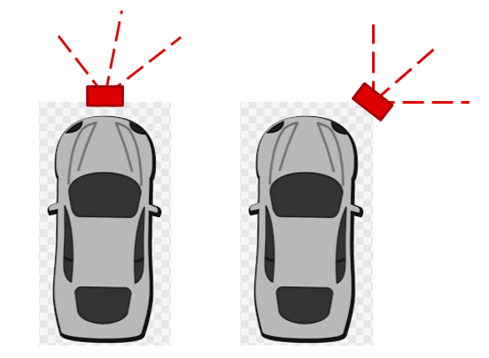

### 2. Launch the Visualizer

> ⚠️ *MATLAB Runtime Version R2017a (9.2)*  
> **Exact version** R2017a (9.2) required. Download from: https://www.mathworks.com/products/compiler/matlab-runtime.html
- Navigate to `<TOOLBOX_INSTALL_DIR>\tools\visualizers\Automated_Parking_GUI`
- There are two gui executables provided:
  - **mmw_demo_parking_xy.exe** displays the 2D point cloud.
  - **mmw_demo_parking_xyz.exe** displays the 3D point cloud.
- Open a DOS cmd window in the gui directory and call the visualizer exe as follows (example below for AOP)
  - `mmw_demo_parking_xyz.exe xwr18xx 42 20 4 41 ../chirp_profiles/profile_parking_mimo_2d_50m_3d_10m_aop.cfg 1`
  - 42: CP2105 Standard COM Port (AOP) - Data
  - 20: Range (m)
  - 4: Width, Height (m)
  - 41: CP2105 Enhanced COM Port (AOP) - CLI
  - 1: loadCfg=1: cli configuration is sent to XWR18xx

This concludes the Quickstart Section

# Developer’s Guide

- Build the firmware from source code
- Work with GUI source code

## Build the Firmware from Source Code

### 1. Software Requirements

[output not shown]

### 2. Import Lab Project

To import the source code into your CCS workspace, CCS projects are provided for the mmWave SDK Out-of-box demo in the Toolbox.

> 📝 *Project Workspace*  
> When importing projects to a workspace, the files are LINKED into the workspace. It is important to note that modifying the files in the CCS workspace will also affect the source files. Practice version control in the case that revisions need to be reverted.
- Start CCS and setup workspace as desired.
- Import the project(s) specified below to CCS. See instructions for importing here

| Project Name | Location in Toolbox |
| --- | --- |
| 18xx_parking_dss | Do not import. Automatically imported with mss project. |
| 18xx_parking_mss | `src` |

- Verify that the import occurred without error: in CCS Project Explorer both **18xx_parking_dss** and **18xx_parking_mss** projects should appear.

> ⚠️ *Error during Import to IDE*  
> If an error occurs, check that the software dependencies listed above have been installed. Errors will occur if necessary files are not installed in the correct location for importing.

### 3. Build the Lab

> 🛑 *MMWAVE SDK 3.5.0.4 DEFECT MUST BE FIXED BEFORE BUILDING THE DEMO*  
> The file **C:\ti\mmwave_sdk_03_05_00_04\packages\ti\board\antenna_geometry.c** must be updated as described in https://e2e.ti.com/support/sensors-group/sensors/f/sensors-forum/1058541/faq-awr1843aop-awr1843aop-mmwave-sdk-3-5-0-4-demo-elevation-bug-fix

> 📝 *Note*  
> The same lab projectspec is provided to support either the AOP or BOOST evm. Users can control which EVM to build for by setting the Active Build Configuration as shown below.
1. Select the **18xx_parking_mss** so it is highlighted. Right click on the project and select **Build Configurations** –> **Set Active** –> **aop** or **boost** based on the EVM
2. Select the **18xx_parking_dss** so it is highlighted. Right click on the project and select **Build Configurations** –> **Set Active** –> **aop** or **boost** based on the EVM
3. Select the **18xx_parking_mss** so it is highlighted. Right click on the project and select **Rebuild Project**. The DSS project will automatically build first and then the MSS project.
4. On successful build, the following should appear:
   - **AOP:**
     - In automated_parking_18xx_dss\aop, **parking_18xx_demo_dss_aop.xe674** (this is the C67x binary used for CCS debug mode)
     - In automated_parking_18xx_mss\aop, **parking_18xx_demo_mss_aop.xer4f** (this is the Cortex R4F binary used for CCS debug mode) and **parking_18xx_demo_aop.bin** (this is the flashable binary used for deployment mode)
   - **BOOST:**
     - In automated_parking_18xx_dss\boost, **parking_18xx_demo_dss_boost.xe674** (this is the C67x binary used for CCS debug mode)
     - In automated_parking_18xx_mss\boost, **parking_18xx_demo_mss_boost.xer4f** (this is the Cortex R4F binary used for CCS debug mode) and **parking_18xx_demo_boost.bin** (this is the flashable binary used for deployment mode)

> 📝 *Note*  
> Please set same Active Build Configuration for both MSS and DSS project.

> 📝 *Note*  
> Selecting Rebuild instead of Build ensures that the project is always re-compiled. This is especially important in case the previous build failed with errors.

> ⚠️ *Build Fails with Errors*  
> If the build fails with errors, please ensure that all the software requirements are installed as listed above and in the mmWave SDK release notes.

> 📝 *Note*  
> As mentioned in the Quickstart section, pre-built binary files, both debug and deployment binaries are provided in the pre-compiled directory of the lab.

### 4. Execute the Compiled Lab

There are two ways to execute the compiled code on the EVM:

- **Deployment mode**: In this mode, the EVM boots autonomously from flash and starts running the bin image
  - Use the **parking_18xx_demo_evm_type.bin** found at `<CCS_PROJECT_WORKSPACE_DIR>\automated_parking_18xx_mss\[Build-Folder]\` and follow the same process in the Quickstart section except flash this binary instead.
- **Debug mode**: This mode is is used for downloading and running the executable from CCS. This mode enables JTAG connection with CCS while the lab is running and is useful during development and debugging.
  - Follow the CCS Debug Mode Guide, using the binaries listed below where EVM type correlates to the selected build configuration .
  - After CCS Debug mode is setup, launch the visualizer and proceed as described in the Run the Lab section of the Quickstart

| Debug binary | Location | Connect and load to |
| --- | --- | --- |
| parking_18xx_demo_dss_evm type.xe674 | `<CCS_PROJECT_WORKSPACE_DIR>\automated_parking_18xx_dss\<EVM-TYPE>\` | C674X_0 |
| parking_18xx_demo_mss_evm type.xer4f | `<CCS_PROJECT_WORKSPACE_DIR>\automated_parking_18xx_mss\<EVM-TYPE>\` | Cortex_R4_0 |

## Work with GUI source code

> ⚠️ Working with and running the visualizer source files requires a full MATLAB license not just the MATLAB Runtime Engine
- The visualizer source files are located at `gui`
- Running the matlab gui file directly results in the same fucntionality as the executable used inthe Quick Start section; please refer to the section for details.
  - `mmw_demo_parking_xyz('xwr18xx' 42, 20, 4, 41, '../chirp_profiles/profile_parking_mimo_2d_50m_3d_10m_aop.cfg', 1)`
- Files of interest:
  - mmw_demo_parking_xyz.m: Main visualizer script for 3D point cloud display.
  - mmw_demo_parking_xy.m: Main visualizer script for 2D point cloud display.

## Chirp Configuration Format

Chirp Configuration Format is documented in the mmWave SDK User Guide. See Need More Help? below.

## Data Output Format

Data Output Format is documented in the mmWave SDK User Guide. See Need More Help? below.

# Need More Help?

- Additional resources in the documentation of the mmWave SDK:
  - mmWave SDK Module Doc located at `<mmwave_sdk_install_dir>/docs/mmwave_sdk_module_documentation.html`
  - mmWave SDK User’s Guide located at `<mmwave_sdk_install_dir>/docs/mmwave_sdk_user_guide.pdf`
- Search for your issue or post a new question on the [mmWave E2E forum](https://e2e.ti.com/support/sensor/mmwave_sensors/f/1023)